# Problema 1

# 1.1 Solutia in forma inchisa

```python
import numpy as np
import matplotlib.pyplot as plt
import seaborn as sns
from sklearn import datasets
import math
```

```python
class LinearRegression(object):
    """
    Modelul de Regresie Liniara
    y = X @ w
        - valoarea prezisă de model
    t ~ N(t|X @ w, var)
        - valorile de antrenare (target) sunt fac parte dintr-o distributie normala in jurul mean-ului X@w,
          la care se adauga zgomot dat de varianta `var`
    """

    def fit(self, X, t):
        """
        Antrenarea modelului in sensul celor mai mici patrate (least squares fitting)
        Parameterii
        ----------
        X : (N, D) np.ndarray
            variabilele de intrare
        t : (N,) np.ndarray
            variabilele tinta (target / ground truth)
        """
        # TODO codul vostru aici: calculati vectorul de ponderi w
        N, D = X.shape
        self.w = np.zeros(D)
        self.w = np.linalg.pinv(X) @ t
        # end

        self.var = np.mean(np.square(X @ self.w - t))

    def predict(self, X, return_std=False):
        """
        Intoarce valoari prezise de model pentru sample-uri X
        Parametrii
        ----------
        X : (N, D) np.ndarray
            sample-uri de valori D-dimensionale pentru care se doreste predictia valorii conform modelului
        return_std : bool, optional
            intoarce deviatia standard a fiecarei valori prezice, daca e setat pe True

        Intoarce
        -------
        y : (N,) np.ndarray
            vector de valori prezise
        y_std : (N,) np.ndarray
            deviatia standard a fiecarei valori prezise
        """
        # TODO codul vostru aici: calculati valoarea prezisa de modelul vostru
        N, D = X.shape
        y = np.zeros(N)

        y = X @ self.w
        # end codul vostru aici

        if return_std:
            # TODO codul vostru aici: intoarceti un vector de aceeasi dimensiune cu y, care
            # are in fiecare pozitie o valoare egala cu deviatia standard a modelului antrenat (i.e. sqrt(var))
            y_std = np.zeros_like(y)
            for i in range(0,len(y_std)-1):
                y_std[i] = np.sqrt(self.var)
            return y, y_std
        return y


def mean_squared_error(y, t):
    return np.mean((y - t) * (y- t))

def root_mean_squared_error(y, t):
    return math.sqrt(np.mean((t - y) * (t - y)))

def split_dataset(X, T, train=.8):
    N = X.shape[0]
    N_train = int(round(N * train))
    N_test = N - N_train

    X_train, X_test = X[:N_train,:], X[N_train:, :]
    T_train, T_test = T[:N_train], T[N_train:]
    return X_train, T_train, X_test, T_test

def extract_polynomial_features(X, M):
    phi = X
    # TODO codul vostru aici: intoarceti valorile phi_n astfel incat pentru fiecare
    # intrare x phi_n = [1, x, x^2, ..., x^M]
    phi =  np.array([x ** np.arange(M + 1) for x in X])
    # end

    # nota: phi trebuie sa fie la final un np.array de dimensiune (N, M+1), unde N este numarul de linii din X
    return phi
```

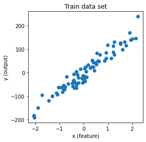

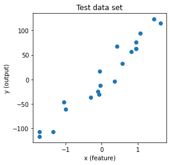

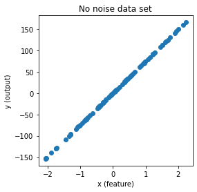

```
Mean Squared Error
Train error: 449.6332334520888
Test  error: 420.7859565018742
Root Mean Squared Error
Train error: 21.204556902988774
Test  error: 20.51306794465114
```

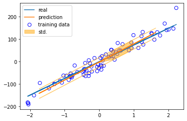

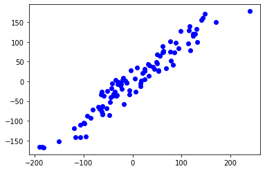

```python
# Simple dataset
n_samples = 100
n_features = 1
noise = 20
X_full, t_full = datasets.make_regression(n_samples=n_samples, n_features=n_features, n_informative=1, noise=noise, random_state=37)
X_train, t_train, X_test, t_test = split_dataset(X_full, t_full)
X_real, t_real = datasets.make_regression(n_samples=n_samples, n_features=n_features, n_informative=1, noise=0., random_state=37)
fig = plt.figure(figsize=(4, 4))
plt.xlabel("x (feature)")
plt.ylabel("y (output)")
plt.title("Train data set")
plt.scatter(X_train, t_train)
plt.show()

fig = plt.figure(figsize=(4, 4))
plt.xlabel("x (feature)")
plt.ylabel("y (output)")
plt.title("Test data set")
plt.scatter(X_test, t_test)
plt.show()

fig = plt.figure(figsize=(4, 4))
plt.xlabel("x (feature)")
plt.ylabel("y (output)")
plt.title("No noise data set")
plt.scatter(X_real, t_real)
plt.show()


model = LinearRegression()
X_train_feat = extract_polynomial_features(X_train, 1)
X_test_feat = extract_polynomial_features(X_test, 1)

model.fit(X_train_feat, t_train)
y_train = model.predict(X_train_feat, False)
y_test, y_test_std = model.predict(X_test_feat, True)

print("Mean Squared Error")
print("Train error:", mean_squared_error(y_train, t_train))
print("Test  error:", mean_squared_error(y_test, t_test))

print("Root Mean Squared Error")
print("Train error:", root_mean_squared_error(y_train, t_train))
print("Test  error:", root_mean_squared_error(y_test, t_test))

plt.scatter(X_train, t_train, facecolor="none", edgecolor="b", s=50, label="training data")
plt.plot(X_real, t_real, label="real")
plt.plot(X_test, y_test, label="prediction")
plt.fill_between(
    np.squeeze(X_test), y_test - y_test_std, y_test + y_test_std,
    color="orange", alpha=0.5, label="std.")
plt.legend()
plt.show()

plt.scatter(t_test, y_test, color="b", label="Quality of predictions")
plt.scatter(t_train, y_train, color="b", label="Quality of predictions")
plt.show()
```

Determinati daca exista sau nu vreo legatura intre valoarea zgomotului utilizat atunci cand sunt generate datele din setul de antrenare si valoarea functiei E(w, b) (5).

Pentru noise=10:

Mean Squared Error

Train error: 112.40830836302219

Test error: 105.19648912546867

Root Mean Squared Error

Train error: 10.602278451494385

Test error: 10.256533972325578

Pentru noise=20:

Mean Squared Error

Train error: 449.6332334520888

Test error: 420.7859565018742

Root Mean Squared Error

Train error: 21.204556902988774

Test error: 20.51306794465114

Pentru noise=40:

Mean Squared Error

Train error: 1798.5329338083552

Test error: 1683.1438260074951

Root Mean Squared Error

Train error: 42.40911380597755

Test error: 41.02613588930226

Pentru noise=60:

Mean Squared Error

Train error: 4046.6991010687984

Test error: 3787.0736085168633

Root Mean Squared Error

Train error: 63.61367070896631

Test error: 61.53920383395339

Eroarea Root Mean Squared este direct proportionala cu valoarea zgomotului. Odata cu cresterea zgomotului, creste si eroarea RMSE. Eroarea RMSE este aproximativ egala cu valoarea zgomotului.

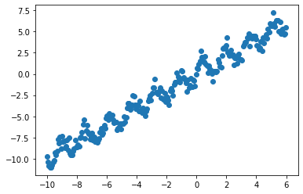

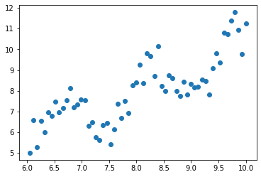

```
Mean Squared Error
Train error: 0.7991977252838114
Test  error: 0.9222999130440788
Root Mean Squared Error
Train error: 0.8939785933028885
Test  error: 0.960364468857568
```

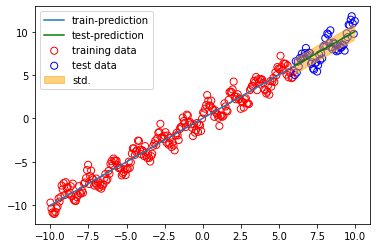

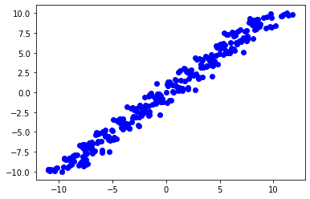

```python
# Complex dataset
n_samples = 300
x = np.linspace(-10, 10, n_samples) # coordinates
noise_sample = np.random.normal(0, 0.5, n_samples)
sine_wave = x + np.sin(4*x) + noise_sample
x = [[xx] for xx in x]
x = np.asarray(x)

X_train, t_train, X_test, t_test = split_dataset(x, sine_wave)
plt.plot(X_train, t_train, 'o');
plt.show()

plt.plot(X_test, t_test, 'o');
plt.show()


model = LinearRegression()
X_train_feat = extract_polynomial_features(X_train, 1)
X_test_feat = extract_polynomial_features(X_test, 1)

model.fit(X_train_feat, t_train)
y_train = model.predict(X_train_feat, False)
y_test, y_test_std = model.predict(X_test_feat, True)

print("Mean Squared Error")
print("Train error:", mean_squared_error(y_train, t_train))
print("Test  error:", mean_squared_error(y_test, t_test))

print("Root Mean Squared Error")
print("Train error:", root_mean_squared_error(y_train, t_train))
print("Test  error:", root_mean_squared_error(y_test, t_test))

plt.scatter(X_train, t_train, facecolor="none", edgecolor="r", s=50, label="training data")
plt.scatter(X_test, t_test, facecolor="none", edgecolor="b", s=50, label="test data")
plt.plot(X_train, y_train, label="train-prediction")
plt.plot(X_test, y_test, color="green", label="test-prediction")
plt.fill_between(
    np.squeeze(X_test), y_test - y_test_std, y_test + y_test_std,
    color="orange", alpha=0.5, label="std.")
plt.legend()
plt.show()

plt.scatter(t_test, y_test, color="b", label="Quality of predictions")
plt.scatter(t_train, y_train, color="b", label="Quality of predictions")
plt.show()
```

Noise=0.2

Mean Squared Error

Train error: 0.5551135219060152

Test error: 0.5985807389777544

Root Mean Squared Error

Train error: 0.7450594083064888

Test error: 0.7736799977883326

Noise=0.5

Mean Squared Error

Train error: 0.7745752353098766

Test error: 0.9643148450326517

Root Mean Squared Error

Train error: 0.8800995598850602

Test error: 0.9819953386002663

Noise = 0.8

Mean Squared Error

Train error: 1.1665210234285652

Test error: 1.2655005018400058

Root Mean Squared Error

Train error: 1.080056027911777

Test error: 1.1249446661236302

# 1.2 Gradient Descent

```python
def cost_function(y, t):
   return 1/2 * np.sum((y - t) * (y- t))

def train_gradient_descent(X, T, lr=.01, epochs_no=100):
  (N, D) = X.shape
  X_hat = np.concatenate([X, np.ones((N, 1))], axis=1)
  W = np.random.randn((D+1))
  error = []
  for i in range(epochs_no):
    y = X_hat @ W
    W = W - lr * np.transpose(X_hat)@(y - T)/N
    error.append(mean_squared_error(y, T))
  return W, error
```

```
Test error = 3240.736442929122 Learning rate = 0.001
```

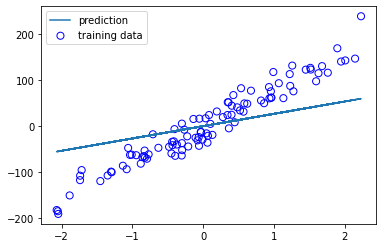

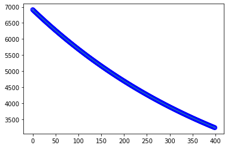

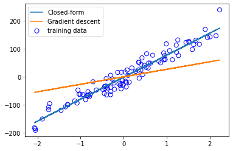

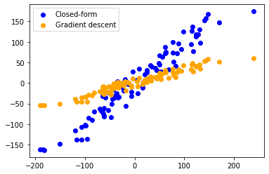

```
Test error = 441.2396847712342 Learning rate = 0.01
```

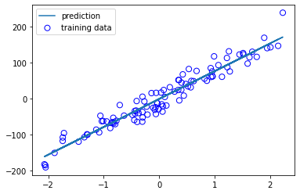

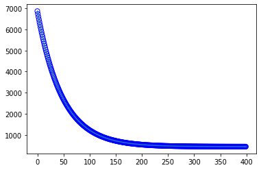

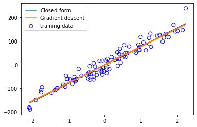

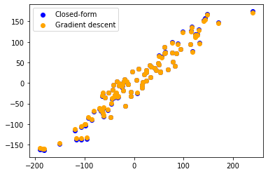

```
Test error = 439.6417796245061 Learning rate = 0.1
```

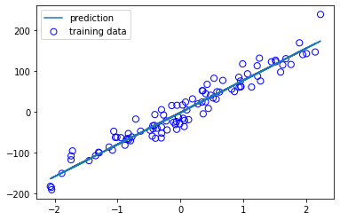

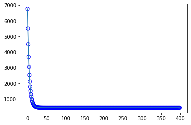

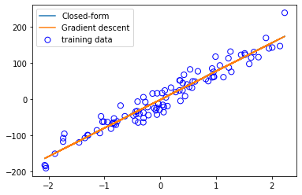

```
Test error = 439.6417796245061 Learning rate = 0.5
```

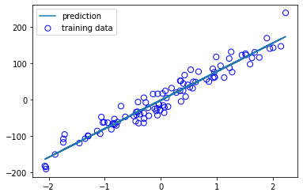

[10 more figures not shown]

```python
# Simple dataset
n_samples = 100
n_features = 1
noise = 20
X_full, t_full = datasets.make_regression(n_samples=n_samples, n_features=n_features, n_informative=1, noise=noise, random_state=37)

errors = {}

model = LinearRegression()
X_full_feat = extract_polynomial_features(X_full, 1)

model.fit(X_full_feat, t_full)

y_full = np.zeros(X_full.size)
y_full = model.predict(X_full_feat, False)


plot_x = [i for i in range(400)]

W, error = train_gradient_descent(X_full, t_full, 10**(-3), 400)
errors[10**(-3)] = error
X_hat = np.concatenate([X_full, np.ones((X_full.shape[0], 1))], axis=1)
Y = X_hat @ W
print("Test error =", error[len(error) - 1], "Learning rate =", 10**(-3))
plt.scatter(X_full, t_full, facecolor="none", edgecolor="b", s=50, label="training data")
plt.plot(X_full, Y, label="prediction")
plt.legend()
plt.show()

plt.plot(plot_x, error)
plt.scatter(plot_x, error, facecolor="none", edgecolor="b", s=50)
plt.show()

plt.scatter(X_full, t_full, facecolor="none", edgecolor="b", s=50, label="training data")
plt.plot(X_full, y_full, label="Closed-form")
plt.plot(X_full, Y, label="Gradient descent")
plt.legend()
plt.show()

plt.scatter(t_full, y_full, color="blue", label="Closed-form")
plt.scatter(t_full, Y, color="orange", label="Gradient descent")
plt.legend()
plt.show()

W, error = train_gradient_descent(X_full, t_full, 10**(-2), 400)
errors[10**(-2)] = error
X_hat = np.concatenate([X_full, np.ones((X_full.shape[0], 1))], axis=1)
Y = X_hat @ W
print("Test error =", error[len(error) - 1], "Learning rate =",10**(-2))
plt.scatter(X_full, t_full, facecolor="none", edgecolor="b", s=50, label="training data")
plt.plot(X_full, Y, label="prediction")
plt.legend()
plt.show()

plt.plot(plot_x, error)
plt.scatter(plot_x, error, facecolor="none", edgecolor="b", s=50)
plt.show()

plt.scatter(X_full, t_full, facecolor="none", edgecolor="b", s=50, label="training data")
plt.plot(X_full, y_full, label="Closed-form")
plt.plot(X_full, Y, label="Gradient descent")
plt.legend()
plt.show()

plt.scatter(t_full, y_full, color="blue", label="Closed-form")
plt.scatter(t_full, Y, color="orange", label="Gradient descent")
plt.legend()
plt.show()

W, error = train_gradient_descent(X_full, t_full, 10**(-1), 400)
errors[10**(-1)] = error
X_hat = np.concatenate([X_full, np.ones((X_full.shape[0], 1))], axis=1)
Y = X_hat @ W
print("Test error =", error[len(error) - 1], "Learning rate =", 10**(-1))
plt.scatter(X_full, t_full, facecolor="none", edgecolor="b", s=50, label="training data")
plt.plot(X_full, Y, label="prediction")
plt.legend()
plt.show()

plt.plot(plot_x, error)
plt.scatter(plot_x, error, facecolor="none", edgecolor="b", s=50)
plt.show()

plt.scatter(X_full, t_full, facecolor="none", edgecolor="b", s=50, label="training data")
plt.plot(X_full, y_full, label="Closed-form")
plt.plot(X_full, Y, label="Gradient descent")
plt.legend()
plt.show()

plt.scatter(t_full, y_full, color="blue", label="Closed-form")
plt.scatter(t_full, Y, color="orange", label="Gradient descent")
plt.legend()
plt.show()

W, error = train_gradient_descent(X_full, t_full, 1/2, 400)
errors[1/2] = error
X_hat = np.concatenate([X_full, np.ones((X_full.shape[0], 1))], axis=1)
Y = X_hat @ W
print("Test error =", error[len(error) - 1], "Learning rate =", 1/2)
plt.scatter(X_full, t_full, facecolor="none", edgecolor="b", s=50, label="training data")
plt.plot(X_full, Y, label="prediction")
plt.legend()
plt.show()

plt.plot(plot_x, error)
plt.scatter(plot_x, error, facecolor="none", edgecolor="b", s=50)
plt.show()

plt.scatter(X_full, t_full, facecolor="none", edgecolor="b", s=50, label="training data")
plt.plot(X_full, y_full, label="Closed-form")
plt.plot(X_full, Y, label="Gradient descent")
plt.legend()
plt.show()

plt.scatter(t_full, y_full, color="blue", label="Closed-form")
plt.scatter(t_full, Y, color="orange", label="Gradient descent")
plt.legend()
plt.show()

W, error = train_gradient_descent(X_full, t_full, 1/5, 400)
errors[1/5] = error
X_hat = np.concatenate([X_full, np.ones((X_full.shape[0], 1))], axis=1)
Y = X_hat @ W
print("Test error =", error[len(error) - 1], "Learning rate =", 1/5)
plt.scatter(X_full, t_full, facecolor="none", edgecolor="b", s=50, label="training data")
plt.plot(X_full, Y, label="prediction")
plt.legend()
plt.show()

plt.plot(plot_x, error)
plt.scatter(plot_x, error, facecolor="none", edgecolor="b", s=50)
plt.show()

plt.scatter(X_full, t_full, facecolor="none", edgecolor="b", s=50, label="training data")
plt.plot(X_full, y_full, label="Closed-form")
plt.plot(X_full, Y, label="Gradient descent")
plt.legend()
plt.show()

plt.scatter(t_full, y_full, color="blue", label="Closed-form")
plt.scatter(t_full, Y, color="orange", label="Gradient descent")
plt.legend()
plt.show()


lr_newton_raphson = 1/max(np.linalg.eigh(np.transpose(X_full) @ X_full))
W, error = train_gradient_descent(X_full, t_full, lr_newton_raphson[0], 400)
errors["NR"] = error
X_hat = np.concatenate([X_full, np.ones((X_full.shape[0], 1))], axis=1)
Y = X_hat @ W
print("Test error =", error[len(error) - 1], "Newton-Raphson Learning rate =", lr_newton_raphson[0])
plt.scatter(X_full, t_full, facecolor="none", edgecolor="b", s=50, label="training data")
plt.plot(X_full, Y, label="prediction")
plt.legend()
plt.show()

plt.plot(plot_x, error)
plt.scatter(plot_x, error, facecolor="none", edgecolor="b", s=50)
plt.show()

plt.scatter(X_full, t_full, facecolor="none", edgecolor="b", s=50, label="training data")
plt.plot(X_full, y_full, label="Closed-form")
plt.plot(X_full, Y, label="Gradient descent")
plt.legend()
plt.show()

plt.scatter(t_full, y_full, color="blue", label="Closed-form")
plt.scatter(t_full, Y, color="orange", label="Gradient descent")
plt.legend()
plt.show()

plt.plot(plot_x, errors[10**(-3)], '-o', label="1.00e-03")
plt.plot(plot_x, errors[10**(-2)], '-o', label="1.00e-02")
plt.plot(plot_x, errors[10**(-1)], '-o', label="1.00e-01")
plt.plot(plot_x, errors[1/2], '-o', label="2.00e-01")
plt.plot(plot_x, errors[1/5], '-o', label="5.00e-01")
plt.plot(plot_x, errors["NR"], '-o', label="Newton-Raphson")
plt.legend()
plt.show()
```